# South Asian Immigration (1996 - 2021) in Scarborough & Markham

Author

Aisha Syed

Discriminatory immigration laws that significantly limited Asian immigration into Canada were lifted in the mid-1960’s, causing a dramatic increase in the number of South Asian immigrants (Li and Lo 2012). After the mid-1960s, there have been major influxes of South Asian immigration in the the mid-1980s and the 1990s through skilled worker and refugee immigration pathways (Ghosh 2014). Recently, there have been efforts to dispel the myth of the South Asian monolith by acknowledging the different immigration contexts of various South Asian migrant groups (Walton-Roberts 2003). Thus, I will analyze the migration of different South Asian ethnic groups in Scarborough and Markham, Ontario. More specifically, I will analyze the spatio-temporal clustering of Indian, Sri Lankan, Pakistani, and Bengali migration from 1996 to 2021. To do this, I will pull data from the Canadian census from the years 1996, 2001, 2006, 2016, and 2021. Data form 2011 will be excluded from the analysis due to bad data quality. In addition, Nepali immigrants are excluded from this study because they are not considered by the census until 2006. I only consider immigrants whose place of birth is any of the countries of interest.

I standardized all census tracts to the 2021 census tract geometry using a weighing factor to adjust the values across all variables and filtered them to Scarborough and Markham.

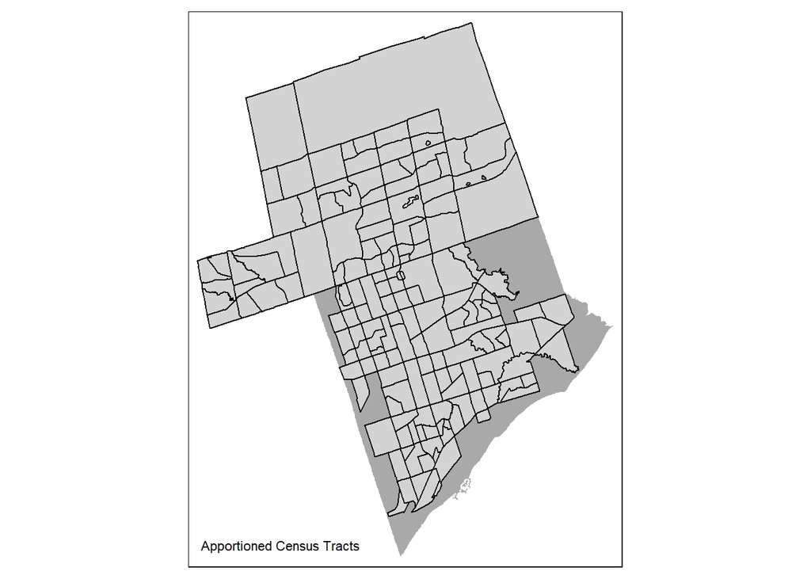

Apportioned Census Tracts (1996 - 2021)

It looks like some census tracts get lost through the process of apportioning past census tracts to the most current 2021 census tracts.

Descriptive Statistics South Asian Immigrant Data

Unique (#)

Missing (%)

Mean

SD

Min

Median

Max

Bangladesh_1996

30

0

3.4

8.7

0.0

0.0

50.0

Bangladesh_2001

39

0

16.1

39.5

0.0

0.0

340.0

[figure not shown]

Bangladesh_2006

57

0

28.6

51.5

0.0

7.5

250.0

[figure not shown]

Bangladesh_2016

43

0

59.3

126.6

0.0

20.0

955.0

[figure not shown]

Bangladesh_2021

50

0

79.0

145.9

0.0

25.0

975.0

[figure not shown]

BangladeshPerc_1996

15

25

0.1

0.2

0.0

0.0

1.0

BangladeshPerc_2001

45

17

0.3

0.7

0.0

0.0

6.2

[figure not shown]

BangladeshPerc_2006

68

17

0.5

0.9

0.0

0.1

5.5

[figure not shown]

BangladeshPerc_2016

93

13

0.9

1.9

0.0

0.3

15.8

[figure not shown]

BangladeshPerc_2021

99

0

1.5

2.5

0.0

0.5

15.6

[figure not shown]

India_1996

125

0

119.4

125.5

0.0

90.6

810.0

[figure not shown]

India_2001

121

0

169.2

195.1

0.0

120.0

1275.0

[figure not shown]

India_2006

112

0

233.2

279.9

0.0

155.0

1995.0

[figure not shown]

India_2016

94

0

258.8

260.1

10.0

171.2

1480.0

[figure not shown]

India_2021

87

0

274.7

260.6

15.0

195.0

1415.0

[figure not shown]

IndiaPerc_1996

102

25

3.0

2.4

0.4

2.2

15.0

IndiaPerc_2001

116

17

3.6

3.4

0.0

2.6

26.4

[figure not shown]

IndiaPerc_2006

124

17

4.4

4.8

0.0

3.2

40.9

[figure not shown]

IndiaPerc_2016

141

13

4.6

4.1

0.4

3.3

30.9

[figure not shown]

IndiaPerc_2021

162

0

5.0

3.8

0.7

4.1

27.9

[figure not shown]

Pakistan_1996

91

0

26.9

28.1

0.0

19.6

158.4

Pakistan_2001

100

0

67.1

88.5

0.0

49.2

690.0

[figure not shown]

Pakistan_2006

83

0

90.4

114.2

0.0

50.0

725.0

[figure not shown]

Pakistan_2016

66

0

95.5

104.8

0.0

59.2

655.0

[figure not shown]

Pakistan_2021

51

0

92.7

99.7

0.0

67.5

600.0

[figure not shown]

PakistanPerc_1996

84

25

0.6

0.6

0.0

0.5

2.8

PakistanPerc_2001

108

17

1.3

1.4

0.0

1.0

10.6

[figure not shown]

PakistanPerc_2006

117

17

1.8

1.9

0.0

1.2

13.8

[figure not shown]

PakistanPerc_2016

129

13

1.7

1.6

0.0

1.2

7.8

PakistanPerc_2021

148

0

1.7

1.5

0.0

1.3

8.5

SouthAsian_1996

138

0

317.8

321.4

0.0

194.9

1530.0

SouthAsian_2001

149

0

473.5

464.0

0.0

315.0

2250.0

SouthAsian_2006

140

0

635.6

581.4

0.0

459.2

2655.0

SouthAsian_2016

131

0

717.8

648.4

10.0

567.5

3415.0

SouthAsian_2021

125

0

724.4

649.6

15.0

557.5

3910.0

SouthAsianPerc_1996

108

25

7.3

5.9

0.4

5.7

32.5

SouthAsianPerc_2001

121

17

9.4

7.9

0.0

7.6

38.5

SouthAsianPerc_2006

124

17

12.1

9.6

0.0

9.9

49.3

SouthAsianPerc_2016

142

13

12.8

9.9

0.4

10.4

43.1

SouthAsianPerc_2021

162

0

13.2

8.9

0.8

11.9

41.5

SriLanka_1996

109

0

168.1

233.6

0.0

53.5

1107.7

SriLanka_2001

121

0

221.1

249.7

0.0

135.0

1135.0

SriLanka_2006

121

0

283.5

287.1

0.0

210.0

1575.0

SriLanka_2016

103

0

304.2

344.4

0.0

207.5

2465.0

[figure not shown]

SriLanka_2021

84

0

278.0

328.0

0.0

197.5

2180.0

[figure not shown]

SriLankaPerc_1996

83

25

3.6

4.6

0.0

1.9

18.5

SriLankaPerc_2001

104

17

4.3

4.5

0.0

2.7

17.5

SriLankaPerc_2006

115

17

5.4

4.8

0.0

4.0

23.3

SriLankaPerc_2016

131

13

5.6

5.5

0.0

4.2

31.1

SriLankaPerc_2021

151

0

5.0

4.7

0.0

4.0

28.7

Next, I will draw upon a spatio-temporal retrospective clustering method that tests for a change point where the data across regions change the most. I will pair this with Global Moran’s I tests to test for clustering across space and time.

# Analysis

```r
SpatTempRetro(SL_num)
```

```
              p-value    sig  minimum p-value?
SriLanka_1996 "3.63e-07" "**" ""
SriLanka_2001 "5.93e-27" "**" ""
SriLanka_2006 "1.17e-34" "**" "YES"
SriLanka_2016 "0.0988"   "+"  ""
```

```r
SpatTempRetro(IN_num)
```

```
           p-value    sig  minimum p-value?
India_1996 "0.348"    ""   ""
India_2001 "2.97e-14" "**" ""
India_2006 "1.43e-33" "**" "YES"
India_2016 "2.8e-05"  "**" ""
```

```r
SpatTempRetro(PK_num)
```

```
              p-value    sig  minimum p-value?
Pakistan_1996 "0.995"    ""   ""
Pakistan_2001 "1.03e-07" "**" ""
Pakistan_2006 "1.05e-22" "**" "YES"
Pakistan_2016 "0.238"    ""   ""
```

```r
SpatTempRetro(BA_num)
```

```
                p-value  sig  minimum p-value?
Bangladesh_1996 "0.0207" "*"  ""
Bangladesh_2001 "0.0278" "*"  ""
Bangladesh_2006 "8e-04"  "**" "YES"
Bangladesh_2016 "0.807"  ""   ""
```

# Moran’s I

```
                Moran's I p-value
Sri Lanka 1996  0.44      1.17e-22
Sri Lanka 2001  0.34      2.03e-14
Sri Lanka 2006  0.32      8.31e-13
Sri Lanka 2016  0.52      2.33e-31
Sri Lanka 2021  0.55      8.18e-35
India 1996      0.33      7.46e-14
India 2001      0.34      1.42e-14
India 2006      0.35      4.77e-16
India 2016      0.41      6.71e-20
India 2021      0.43      1.21e-21
Pakistan 1996   0.28      2.59e-10
Pakistan 2001   0.26      8.53e-10
Pakistan 2006   0.25      1.11e-08
Pakistan 2016   0.31      2.33e-12
Pakistan 2021   0.31      1.3e-12
Bangladesh 1996 0.34      1.22e-14
Bangladesh 2001 0.38      1.18e-20
Bangladesh 2006 0.61      3.95e-42
Bangladesh 2016 0.62      5.53e-48
Bangladesh 2021 0.66      5.14e-52
```

## References

Ghosh, Sutama. 2014. “A Passage to Canada: The Differential Migrations of South Asian Skilled Workers to Toronto.” *Journal of International Migration and Integration* 15 (4): 715–35. https://doi.org/10.1007/s12134-013-0298-0.

Li, Wei, and Lucia Lo. 2012. “New Geographies of Migration?: A Canada-U.S. Comparison of Highly Skilled Chinese and Indian Migration.” *Journal of Asian American Studies* 15 (1): 1–34. https://doi.org/10.1353/jaas.2012.0005.

Walton-Roberts, Margaret. 2003. “Transnational Geographies: Indian Immigration to Canada.” *The Canadian Geographer/Le G?ographe Canadien* 47 (3): 235–50. https://doi.org/10.1111/1541-0064.00020.